# Exercise 8: Data Visualization for Exploration

Oliver Nemeth

## Section 1: `palmerpenguins` plots

Here we will use a different data set and again build on skills in this lesson and previous lessons to create exploratory graphics. Here, we will use the `palmerpenguins` dataset, which is designed for just this. Data were collected and made available by Dr. Kristen Gorman and the Palmer Station, Antarctica Long Term Ecological Research Network (LTER).

```r
# Load packages
library(tidyverse)
 install.packages("palmerpenguins")
```

```
## Error in contrib.url(repos, "source"): trying to use CRAN without setting a mirror
```

```r
library(palmerpenguins)
library(here)
# Take a quick look at the penguins data
glimpse(penguins) #a tidy version of str()
```

```
## Rows: 344
## Columns: 8
## $ species           <fct> Adelie, Adelie, Adelie, Adelie, Adelie, Adelie, Adel…
## $ island            <fct> Torgersen, Torgersen, Torgersen, Torgersen, Torgerse…
## $ bill_length_mm    <dbl> 39.1, 39.5, 40.3, NA, 36.7, 39.3, 38.9, 39.2, 34.1, …
## $ bill_depth_mm     <dbl> 18.7, 17.4, 18.0, NA, 19.3, 20.6, 17.8, 19.6, 18.1, …
## $ flipper_length_mm <int> 181, 186, 195, NA, 193, 190, 181, 195, 193, 190, 186…
## $ body_mass_g       <int> 3750, 3800, 3250, NA, 3450, 3650, 3625, 4675, 3475, …
## $ sex               <fct> male, female, female, NA, female, male, female, male…
## $ year              <int> 2007, 2007, 2007, 2007, 2007, 2007, 2007, 2007, 2007…
```

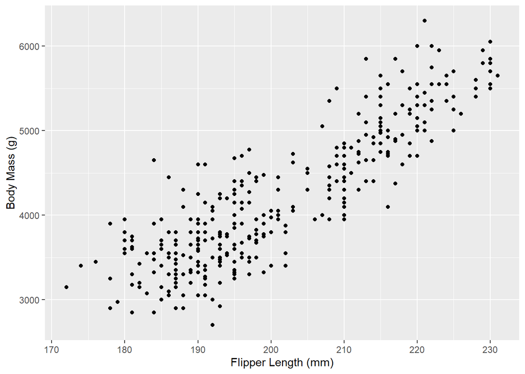

```r
# Create a scatterplot of flipper length vs. body mass
ggplot(data = penguins, aes(x = flipper_length_mm, y = body_mass_g)) +
  geom_point() +
  labs(x = "Flipper Length (mm)", y = "Body Mass (g)")
```

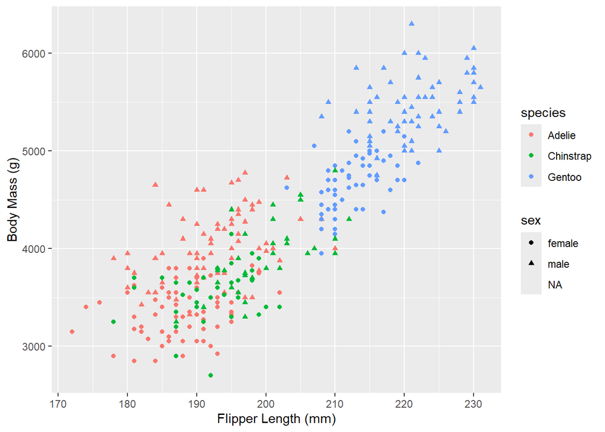

```r
# Update the above plot to use species as color and sex as shape
ggplot(data = penguins, aes(x = flipper_length_mm, y = body_mass_g)) +
  geom_point(aes(color=species, shape=sex)) +
  labs(x = "Flipper Length (mm)", y = "Body Mass (g)")
```

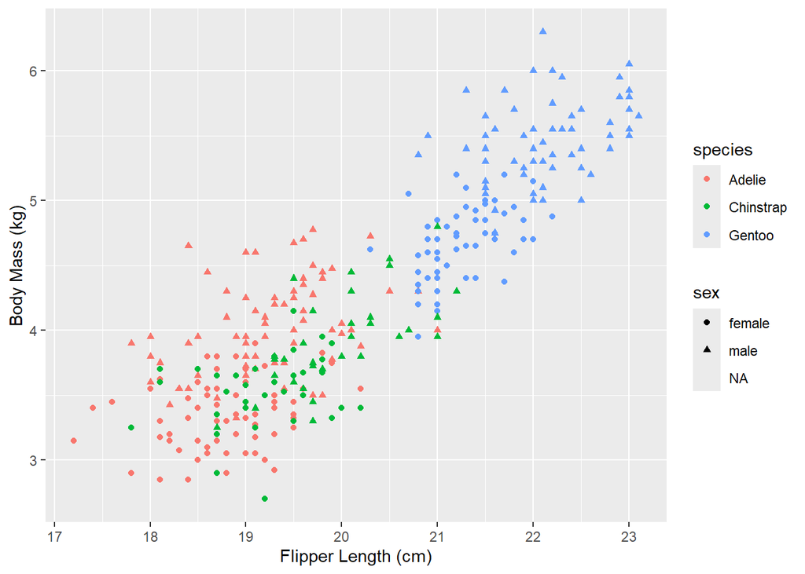

```r
# Update the above scatter plot to measure flipper length in cm and body mass in kg
penguins %>%
  mutate(flipper_length_mm=flipper_length_mm/10,
         body_mass_g=body_mass_g/1000) %>%
  ggplot(aes(x = flipper_length_mm, y = body_mass_g)) +
  geom_point(aes(color = species, shape = sex)) +
  labs(x = "Flipper Length (cm)", y = "Body Mass (kg)")
```

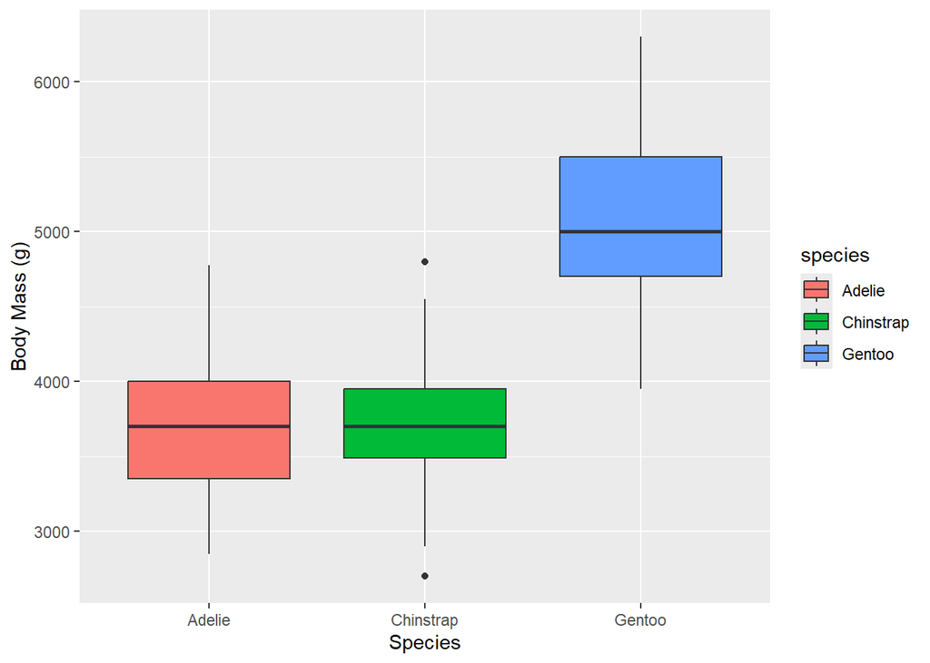

```r
# Make a boxplot showing the distribution of body mass for each species,
# with boxes colored by species
ggplot(penguins, aes(x = species, y = body_mass_g, fill = species)) +
  geom_boxplot() +
  labs(x = "Species", y = "Body Mass (g)")
```

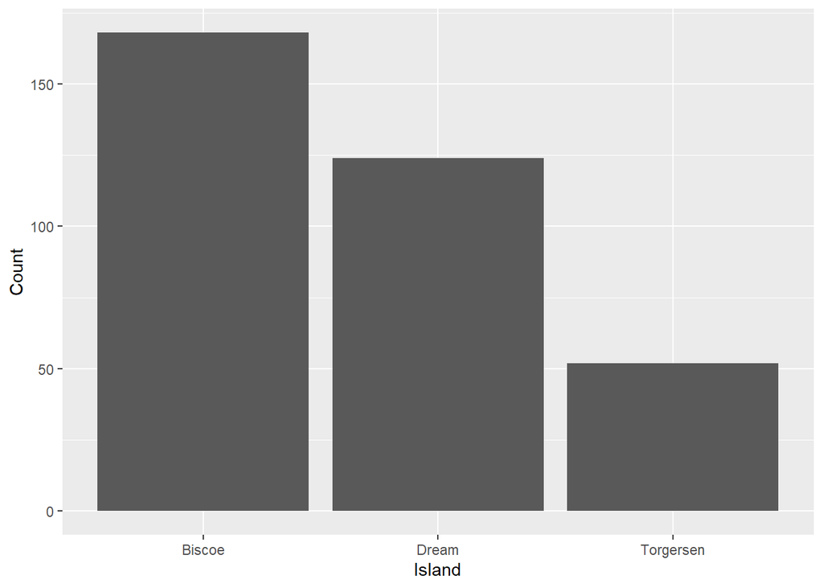

```r
# Plot the number of observations per island using a bar chart
ggplot(penguins, aes(x = island)) +
  geom_bar() +
  labs(x = "Island", y = "Count")
```

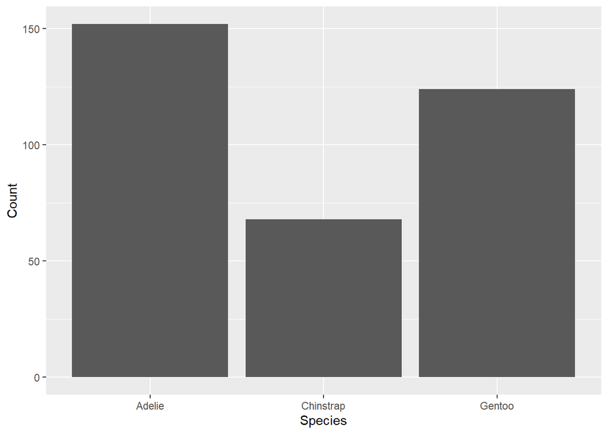

```r
# Plot the number of observations per species using a column chart

penguins_n <- penguins %>%
  group_by(species) %>%
  summarize(count=n())

ggplot(penguins_n, aes(x = species, y=count)) +
  geom_col() +
  labs(x = "Species", y = "Count")
```

What is the difference between `geom_col()` and `geom_bar()`?

*In this instance geom_col needs y=count while geom_bar will just assume that the y is count if you do not include it, geom_bar does not include a y axis.*

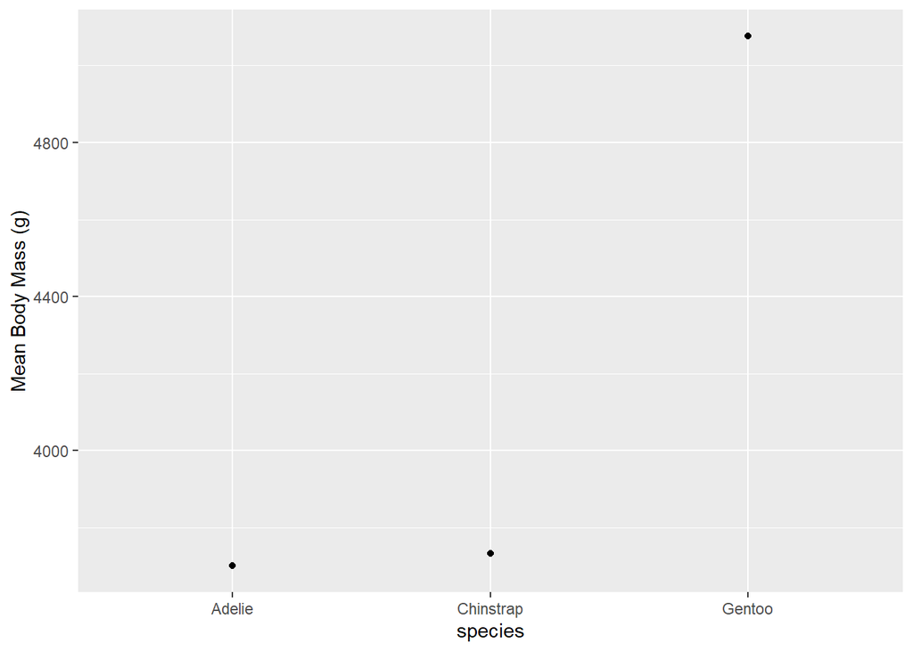

```r
# Create a summary of average body mass by species and plot it as points
avg_mass <- penguins %>%
  group_by(species) %>%
  summarize(mean_mass= mean(body_mass_g, na.rm=TRUE) )

ggplot(avg_mass, aes(x = species, y = mean_mass)) +
  geom_point() +
  labs(y = "Mean Body Mass (g)")
```

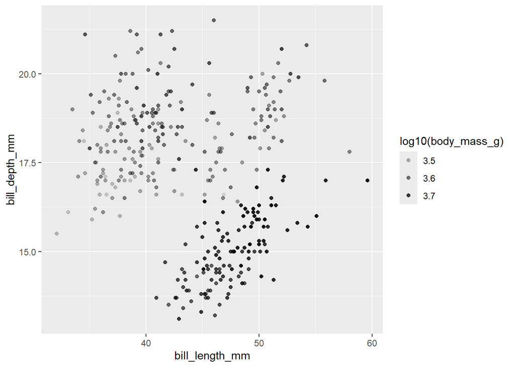

```r
# Create a scatterplot of bill length vs bill depth, adding some transparency
# to handle overlapping points
ggplot(penguins, aes(x = bill_length_mm, y = bill_depth_mm, alpha = log10(body_mass_g))) +
  geom_point()
```

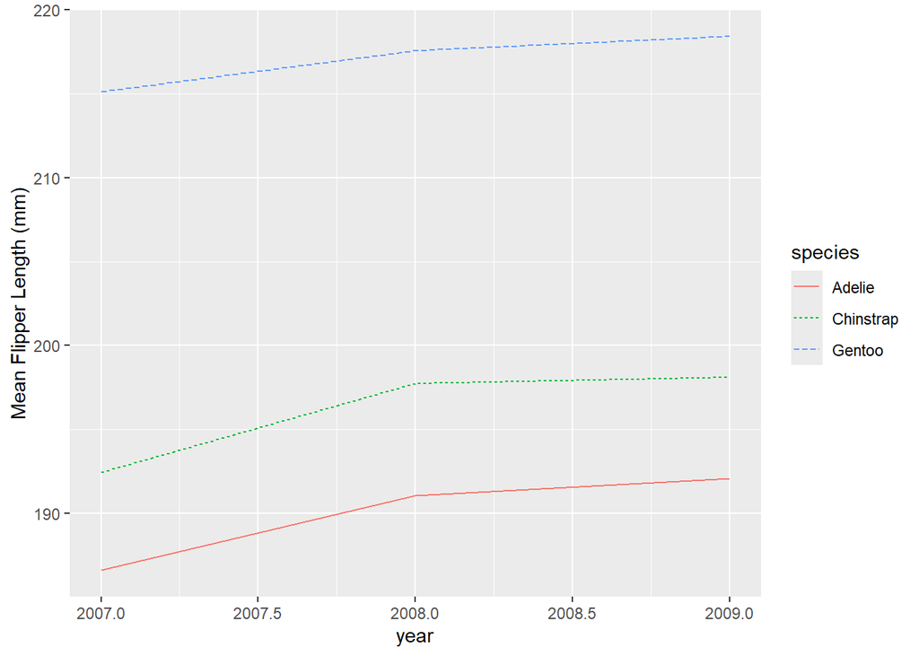

```r
# Create a line plot of average flipper length by year, per species
penguin_avg <- penguins %>%
  group_by(year, species,) %>%
  summarize(mean_flipper = mean(flipper_length_mm, na.rm = TRUE))
p_flip <- ggplot(penguin_avg, aes(x = year, y = mean_flipper,
                        color = species, linetype = species,
                        group = species)) +
  geom_line() +
  labs(y = "Mean Flipper Length (mm)")
p_flip
```

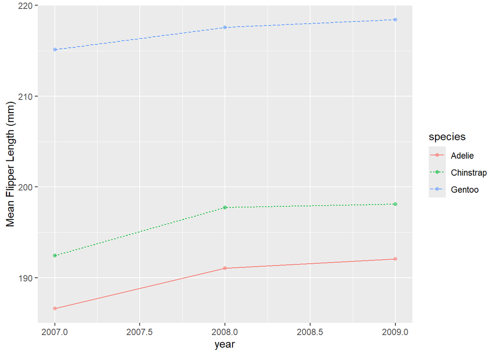

```r
# Add points to this plot
p_flip +
  geom_point(data = penguin_avg, aes(y = mean_flipper),
             alpha = 0.5)
```

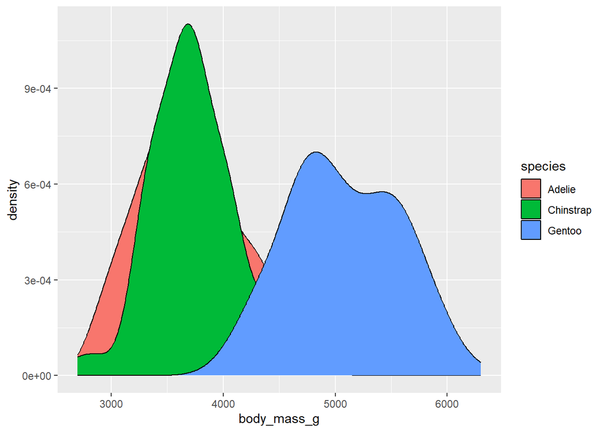

```r
# Plot the distribution of body mass by species
# Using a density plot
ggplot(penguins, aes(x=body_mass_g,fill=species)) +
  geom_density()
```

Working more with summary statistics:

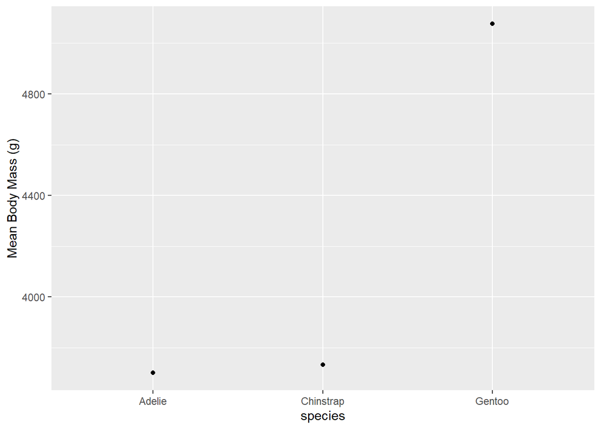

```r
# Use ggplot's automatic summaries to create the same plot as above
# Showing average body mass by species as points
ggplot(penguins, aes(x = species, y =body_mass_g)) +
  stat_summary(geom = "point", fun = "mean") +
  labs(y = "Mean Body Mass (g)")
```

[output not shown]

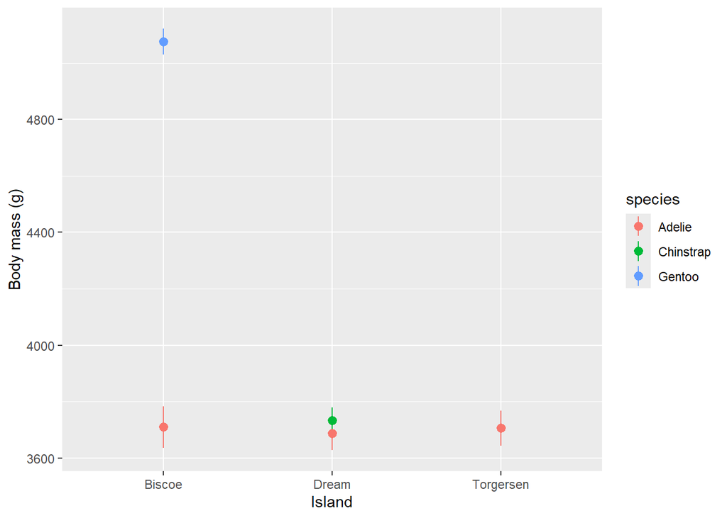

```r
# Create a plot showing the mean and standard error of body mass
# By species (color) and island (axis)
ggplot(penguins, aes(x = island, y = body_mass_g, color =species)) +
  stat_summary() +
  labs(x = "Island", y = "Body mass (g)")
```

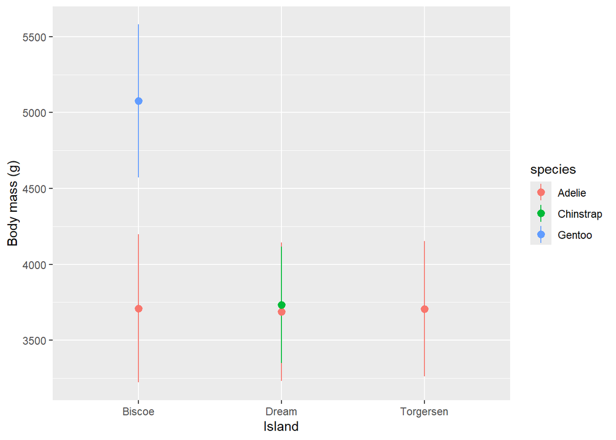

```r
# Update this same plot to show the mean and one standard deviation of the mean
# Hint: there is an example in the help page for stat_summary()
ggplot(penguins, aes(x = island, y = body_mass_g, color = species)) +
  stat_summary(fun.data = "mean_sdl", fun.args = list(mult=1)) +
  labs(x = "Island", y = "Body mass (g)")
```

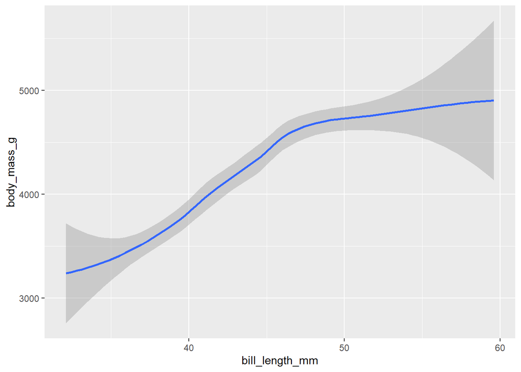

```r
# Create a plot showing a smoothed relationship
# of bill length as a function of body mass
ggplot(penguins, aes(x = bill_length_mm, y = body_mass_g)) +
  geom_smooth()
```

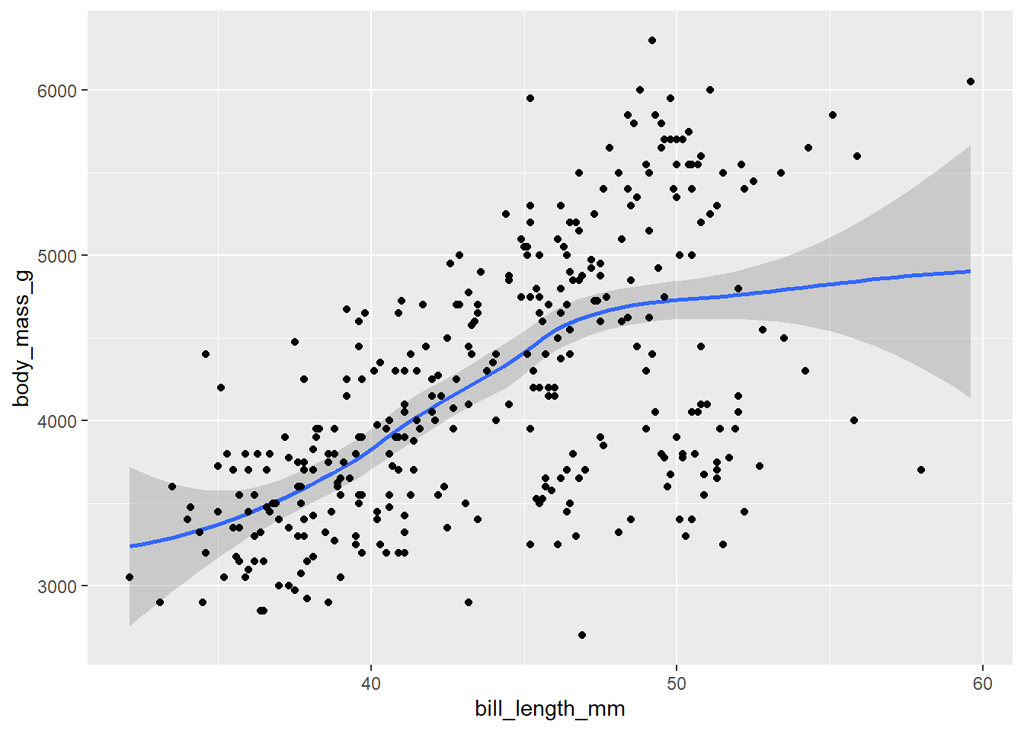

```r
# Add scatterplot points to this plot
ggplot(penguins, aes(x = bill_length_mm, y = body_mass_g)) +
  geom_smooth() +
  geom_point()
```

What does the shaded area produced by `geom_smooth()` represent?

*It is the confidence interval around the trend line*

To practice joining and plotting in space, let’s add some information about the islands:

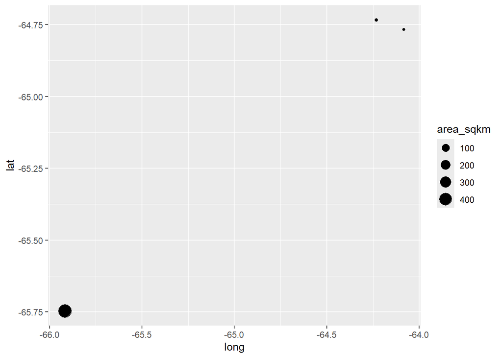

```r
island_info <- data.frame(island_name = c("Torgersen", "Biscoe", "Dream"),
                          area_sqkm = c(0.126, 478.38, 1.678),
                          long = c(-64.0833, -65.9164, -64.2333),
                          lat = c(-64.7667, -65.7474, -64.7333))

# Plot island locations and area as a map
ggplot(island_info,
       aes(x = long, y = lat,
           size = area_sqkm)) +
  geom_point()
```

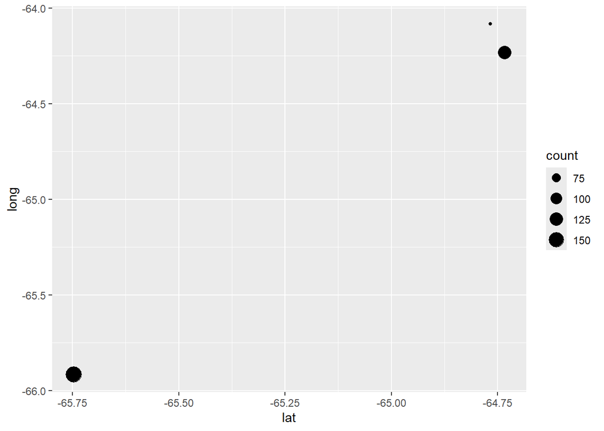

```r
island_info <-rename(island_info, island=island_name)

# Combine the penguin data with the island information
penguins_isl <- left_join(island_info, penguins, by = "island")

# Plot number of penguins sampled per island as a map#you might need more than one argument here; one placeholder given
map_n <- penguins_isl %>%
  group_by(island, lat, long) %>%
  summarize(count=n()) %>%
  ggplot(aes(x = lat, y = long, size = count)) +
  geom_point()
map_n
```

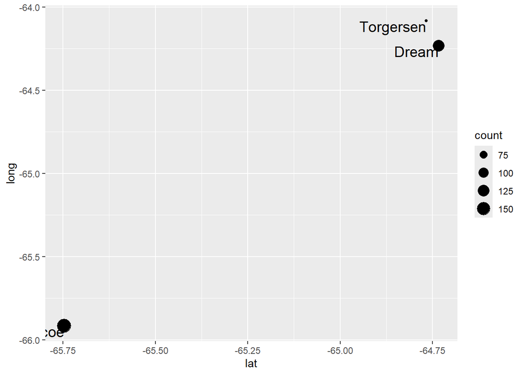

```r
# Add labels to the plot for each island
map_n1 <- map_n +
  geom_text(data = island_info, aes(label = island),
            size = 5, hjust = 1, vjust = 1)
map_n1
```

Play with the `hjust` and `vjust` arguments above. What do these do?

*they adjust the labels horizontally and vertically*

Different data used for map_n1, why would it be different if you used penguins or penguins_isl instead of island_info

*you use the island_info data because the island info is more specific and contains less unrelated columns to the map*

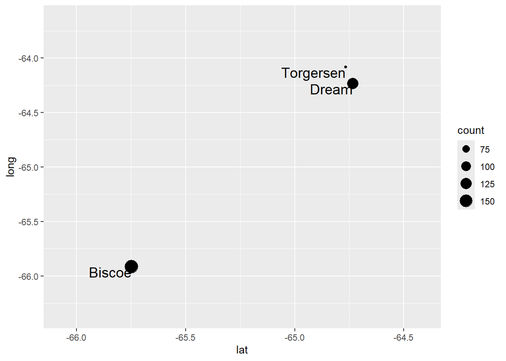

```r
# Expand the axis so you can actually see the labels
map_n2 <- map_n1 +
  scale_y_continuous(expand = c(0.2,0.2)) +
  scale_x_continuous(expand = c(0.2,0.2))
map_n2
```

## Section 2: Open-ended practice

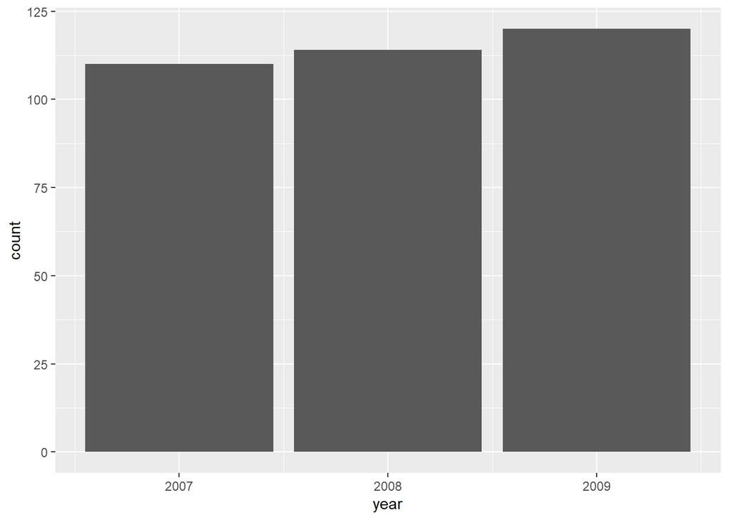

```r
# Create a column/bar plot of the number of individuals sampled per year

ggplot(penguins_isl, aes(x=year))+geom_bar()
```

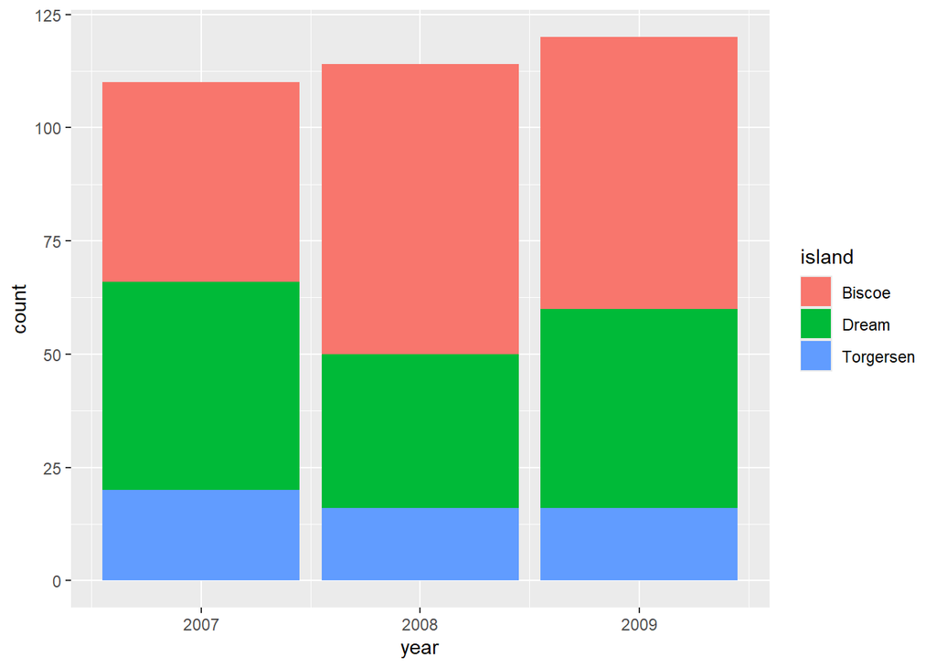

```r
# Add colors by island to this plot as a stacked bar/column chart
ggplot(penguins_isl, aes(x=year, fill=island))+geom_bar()
```

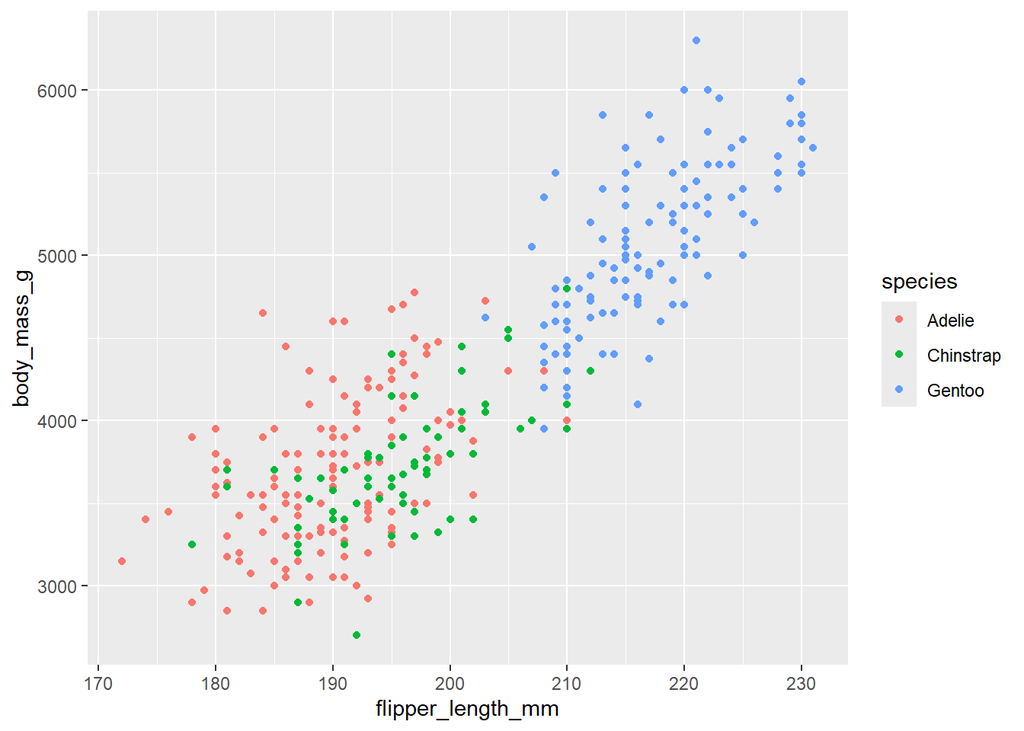

```r
# Scatterplot of flipper length as a function of body mass, colored by species,
# and save it as a named object

flipmass <- ggplot(penguins_isl, aes(x=flipper_length_mm, y=body_mass_g, color=species))+geom_point()

flipmass
```

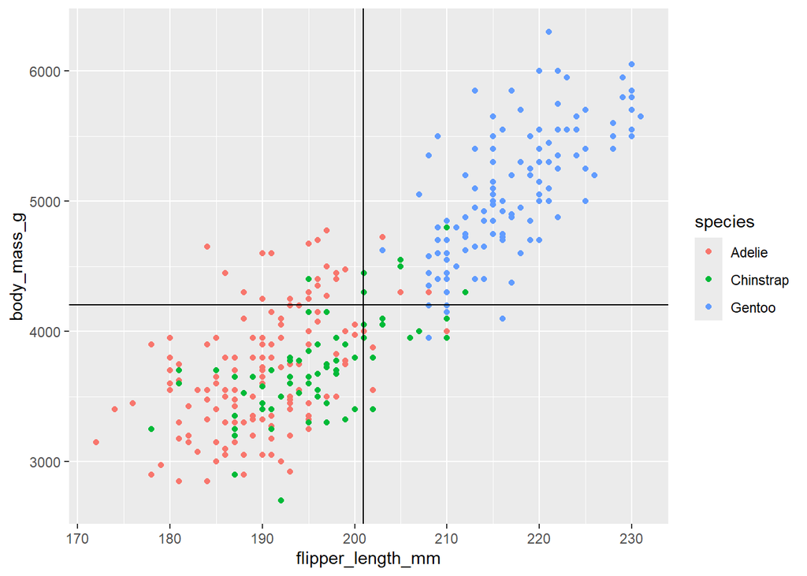

```r
# Add another element: a horizontal line for mean flipper length
# and a vertical line for mean body mass

 flipmass2  <- ggplot(penguins_isl, aes(x=flipper_length_mm, y=body_mass_g, color=species))+
 geom_point()+ geom_hline(yintercept = 4201.754)+geom_vline(xintercept = 200.9152)

 flipmass2
```

```r
 mean(penguins_isl$flipper_length_mm, na.rm=TRUE)
```

```
## [1] 200.9152
```

```r
 mean(penguins_isl$body_mass_g, na.rm=TRUE)
```

```
## [1] 4201.754
```

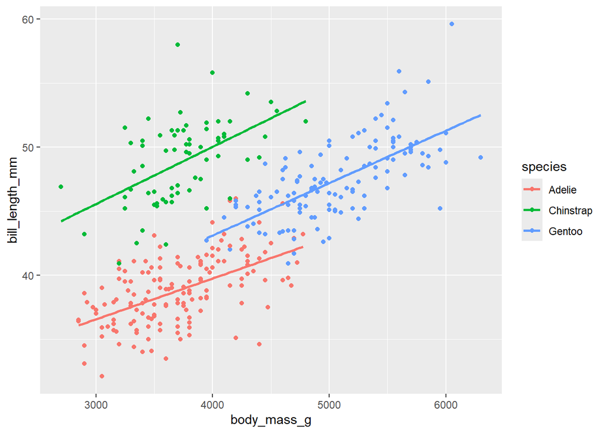

```r
# Plot the scaling relationship between body mass and bill length
# Separately per species
# Include points and a line derived from a *linear model*
# (this can be done within ggplot, no need to run a separate model)

 ggplot(penguins_isl, aes(x=body_mass_g, y=bill_length_mm, color=species))+
   geom_point()+
   geom_smooth(method="lm", se= FALSE)
```

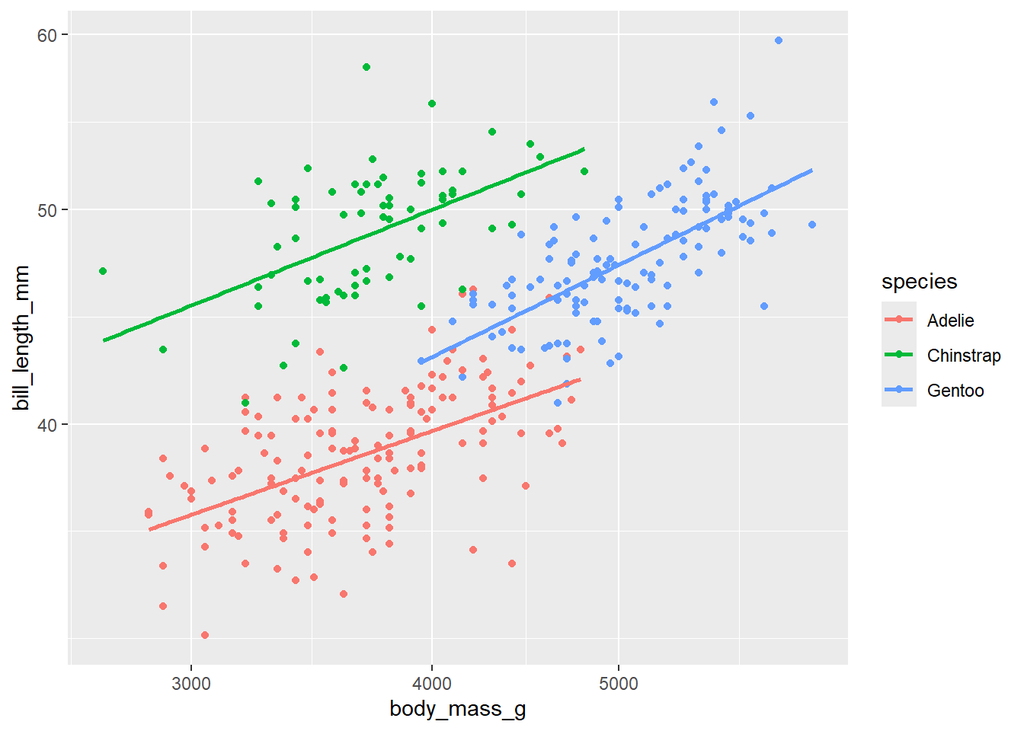

```r
# Update the plot to transform both size measurements to a log10 scale

ggplot(penguins_isl, aes(x= body_mass_g, y= bill_length_mm, color=species))+
   geom_point()+
   geom_smooth(method="lm", se= FALSE)+
  scale_x_continuous(trans="log10")+
   scale_y_continuous(trans="log10")
```

What does this plot show? (i.e., how would you describe the main message(s) of the plot?)

*this plot shows the positive correlation between body mass and bill length across the three speceis of penguin*

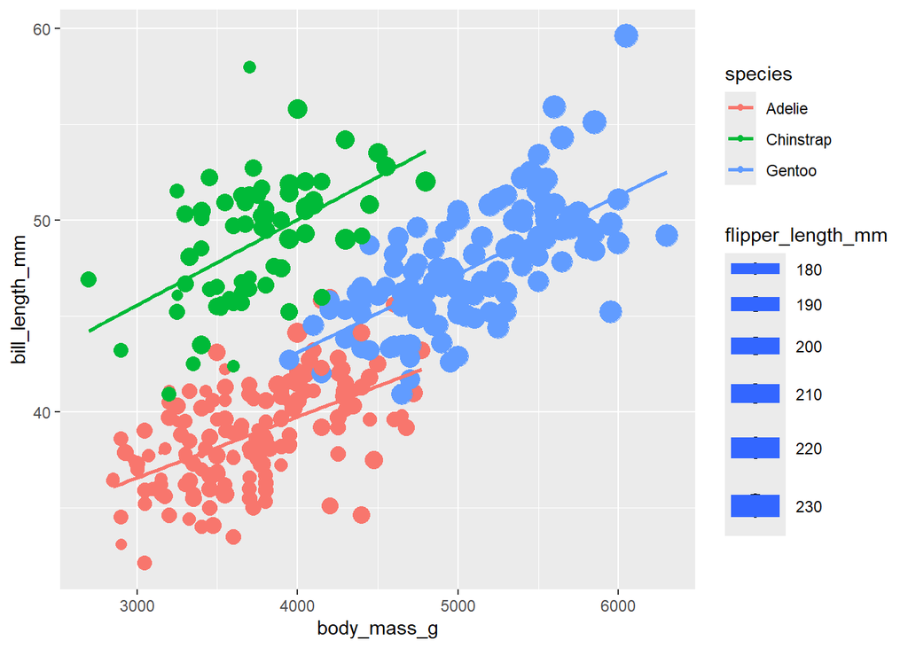

```r
# Create one more plot that includes at least one non-axis aesthetic
# (e.g., color, size)
ggplot(penguins_isl, aes(x=body_mass_g, y=bill_length_mm, color=species, size=flipper_length_mm))+
   geom_point()+
   geom_smooth(method="lm", se= FALSE)
```

What are two different types of plots you can use to visualize distributions?

*histograms and bar plots*

When would you choose to use each one?

*a histogram is good when you have one category you want to count the frequency of and a bar plot is good when you have several categories you want to compare the counts of*